# Learning activity: simple linear regression

Tian Zheng

December 1, 2015

In this example, we are going to use the dataset `state.x77` that comes with standard `R` installation. It is a data set about the 50 states of united states.

Type `help(state.x77)` in your console window to read more about this data set.

```r
data(state.x77)
statedata=as.data.frame(state.x77)
```

There are 8 variables in this data set. The “individuals” of this data set are the 50 states.

```
Population: population estimate as of July 1, 1975

Income: per capita income (1974)

Illiteracy:illiteracy (1970, percent of population)

Life Exp: life expectancy in years (1969–71)

Murder: murder and non-negligent manslaughter rate per 100,000 population (1976)

HS Grad: percent high-school graduates (1970)

Frost: mean number of days with minimum temperature below freezing (1931–1960) in capital or large city

Area: land area in square miles
```

First we can modify the column names (the variable names) for easier use. The function `colnames` can be used to retrieve the colume names or assign new names.

```r
colnames(statedata)=c("popu", "inc", "illit", "life.exp", "murder", "hs.grad", "frost", "area")
```

### Make a scatterplot.

For this example, let’s look at the association between life expectancy (`life.exp`) and income (`inc`). The scatterplot below shows a positive association between these two variables.

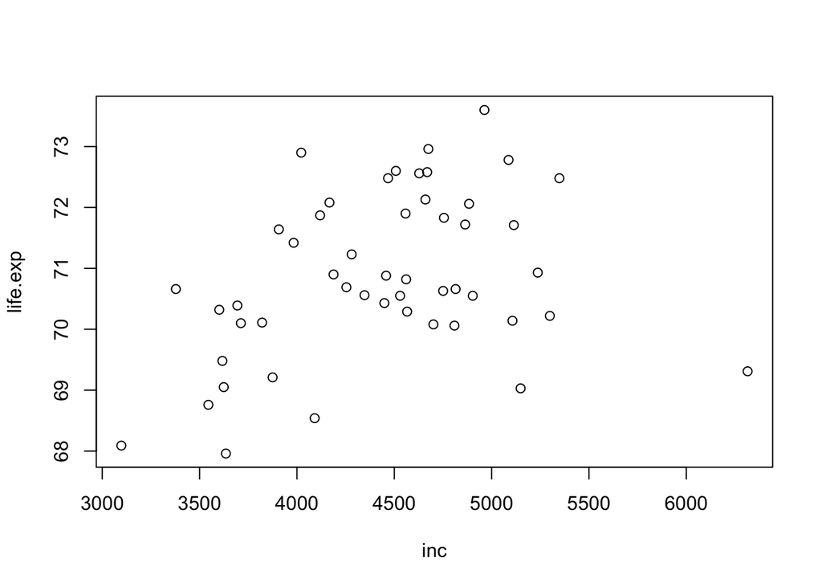

```r
plot(life.exp~inc, data=statedata)
```

We can compute the correlation between these two variables. The value of the correlation indicates a weak positive linear association.

```r
cor(statedata[,"life.exp"], statedata[,"inc"])
```

```
## [1] 0.3402553
```

There is one observation that is far away from the rest of the points. We would like to know which state is corresponding to that point. Let’s add state abbreviations to the plot.

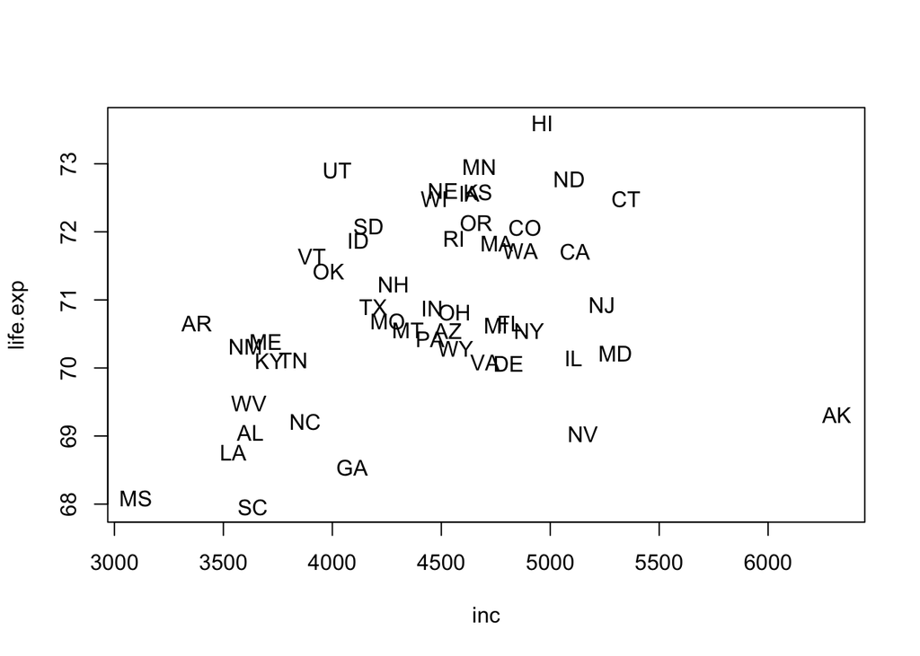

```r
plot(life.exp~inc, data=statedata, type="n")
text(life.exp~inc, data=statedata, state.abb)
```

### Fit a simple linear regression

Now let’s fit the following linear regression model between $Y$ (`life.exp`) and $X$ (`inc`) $Y= \beta_0 +\beta_1 X + \varepsilon.$

Here $\beta_0$ and $\beta_1$ are the regression coefficients of the model and $\varepsilon$ represents independent random errors.

Fitting a linear regression is to derive $\hat{Y} = b_0 + b_1 X.$ Here $\hat{Y}$ is a fitted prediction for the observed life expectancies. The difference $Y - \hat{Y}$ is the prediction error, or residual.

$b_0$ and $b_1$ are estimates for the regression coefficients. They are identified via the least square regression method that minimizes $\sum_{i=1}^n (Y - \hat{Y})^2,$ i.e., the sum of squared prediction errors.

```r
model1=lm(life.exp~inc, data=statedata)
model1
```

```
##
## Call:
## lm(formula = life.exp ~ inc, data = statedata)
##
## Coefficients:
## (Intercept)          inc
##   6.758e+01    7.433e-04
```

In the above output, the intercept is $b_0$ and the coeffient under the column (`inc`) is $b_1$–the slope. The slope is estimated to be $7.4\times 10^{-4}$. The maganitude of this value does not mean that the effect of income on life expectance is very small. This maganitude is decided by the maganitude of the $X$ variable and $Y$ variable.

### Sampling uncertainty in regression analysis

Consider a population of 50 states and we identify the true regression line in this population. Here the function `abline` add a straight line to an existing plot.

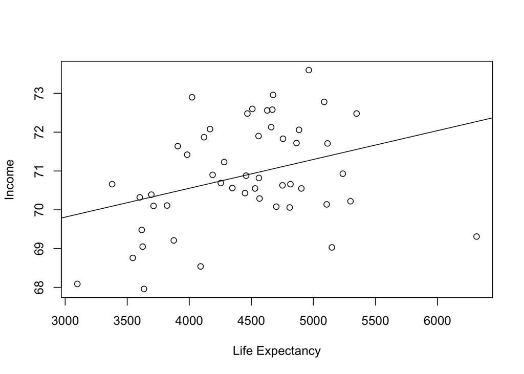

```r
plot(life.exp~inc, data=statedata,
      xlab="Life Expectancy", ylab="Income")
abline(model1)
```

Now we can consider 4 random samples. We use a [`for` loop](https://en.wikipedia.org/wiki/For_loop) to run an identical regression analysis on 4 randomly selected samples.

Within the loop, we will implement the following steps for each repetition.

- Step 1: randomly select 10 states using the `sample` function of `R`.
- Step 2: run least square regression on the selected states only
- Step 3: compute a 95% confidence band for the true regression line in the population using the sample.

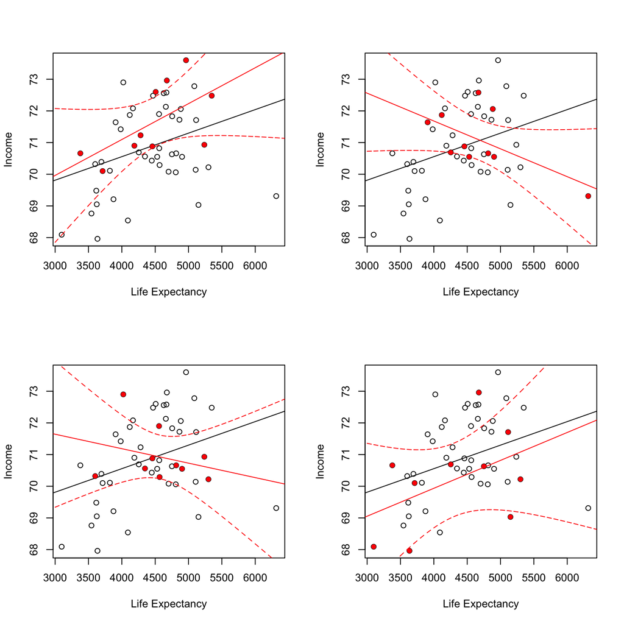

```r
par(mfrow=c(2,2)) # create a panel of four plotting areas

for(i in 1:4){
  ## Plot the population
  plot(life.exp~inc, data=statedata,
       xlab="Life Expectancy", ylab="Income")
  abline(model1)
  ## Select the sample
  selected.states=sample(1:50, 10)
  points(statedata[selected.states,"inc"],
         statedata[selected.states,"life.exp"], pch=16, col=2)
  ## Fit a regression line using the sample
  model.sel = lm(life.exp~inc, data=statedata[selected.states,])
  abline(model.sel, col=2)
  ## Make a confidence band.
  #### first calculate the width of the band, W.
  ww=sqrt(2*qf(0.95, 2, nrow(statedata)-2))
  #### generate plotting X values.
  plot.x<-data.frame(inc=seq(3000, 7000, 1))
  #### se.fit=T is an option to save
  #### the standard error of the fitted values.
  plot.fit<-predict(model.sel, plot.x,
                    level=0.95, interval="confidence",
                    se.fit=T)

  #### lines is a function to add connected lines
  #### to an existing plot.
  lines(plot.x$inc, plot.fit$fit[,1]+ww*plot.fit$se.fit,
        col=2, lty=2)
  lines(plot.x$inc, plot.fit$fit[,1]-ww*plot.fit$se.fit,
        col=2, lty=2)
}
```